# SLeep Coffee Productivity Portfolio

Its like Juppiter Notebook but for science

Run Chunk *Ctrl+Shift+Enter* Add Chunck *Ctrl+Alt+I* HTML Preview *Ctrl+Shift+K*

```r
print("Portfolio Assignment")
```

```
[1] "Portfolio Assignment"
```

```r
myData <- read.csv('./data/sleepCoffeeProductivity.csv')
cat("Is data a dataframe: ", is.data.frame(myData), "\n")
```

```
Is data a dataframe:  TRUE
```

```r
cat("Dataset Contains: ", ncol(myData), " Attributes\n")
```

```
Dataset Contains:  14  Attributes
```

```r
cat("Dataset Contains: ", nrow(myData), " Instances")
```

```
Dataset Contains:  35  Instances
```

```r
print("Preliminary Eyeball Data: ")
```

```
[1] "Preliminary Eyeball Data: "
```

```r
cat("Max Morning Productivity: ", max(myData$Day.Productivity), "\n")
```

```
Max Morning Productivity:  3
```

```r
cat("Mean Morning Productivity: ", mean(myData$Day.Productivity), "\n\n")
```

```
Mean Morning Productivity:  1.332857
```

```r
cat("Max Night Productivity: ", max(myData$Night.Time.Productivity), "\n")
```

```
Max Night Productivity:  3
```

```r
cat("Mean Night Productivity: ", mean(myData$Night.Time.Productivity))
```

```
Mean Night Productivity:  1.45
```

First Test, Am I a morning person or a night person. T Test. We want to Aswer the question of whether I am Morning person or night person. Is more work done when sun is up or sun is down?

We use students t test on two samples of day time productivity and night time

```r
t.test(myData$Day.Productivity, myData$Night.Time.Productivity, paired=TRUE)
```

```
    Paired t-test

data:  myData$Day.Productivity and myData$Night.Time.Productivity
t = -0.69024, df = 34, p-value = 0.4947
alternative hypothesis: true difference in means is not equal to 0
95 percent confidence interval:
 -0.4620398  0.2277541
sample estimates:
mean of the differences
             -0.1171429
```

Fishers Exact

Addicted to Coffe or not?

```r
addictP <- sum(dhyper(4:10, 10,25,9))
cat("Our P value to test for addiction is: ", addictP, " Our p value is: ", addictP*100, "%")
```

```
Our P value to test for addiction is:  0.2105335  Our p value is:  21.05335 %
```

The probability if we do not have an addiction, of seeing the observation (X = 4) or an observation more extreme. The p value is not significant from we obs. We fail to reject the null

I do not have an addiction to caffene.

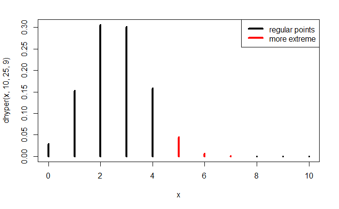

```r
#Verify
x <- 0:10
plot(x, dhyper(x,10,25,9),type='h',lwd=4,col=c(rep("black",5),rep("red",3)))
legend("topright",lwd=4, col=c("black","red"),legend=c("regular points","more extreme"))
```

```r
addictMatrix <- matrix(c(4,6,5,20),2,2,byrow=TRUE)
dimnames(addictMatrix) <- list (week=c("End","Day"),  drinkingHabit=c("Abuse","Normal") )
addictMatrix
```

```
     drinkingHabit
week  Abuse Normal
  End     4      6
  Day     5     20
```

```r
fisher.test(addictMatrix, alternative="greater")
```

```
    Fisher's Exact Test for Count Data

data:  addictMatrix
p-value = 0.2105
alternative hypothesis: true odds ratio is greater than 1
95 percent confidence interval:
 0.5028273       Inf
sample estimates:
odds ratio
   2.58449
```

Poisson distribution test whether more cups of coffe is = productivity. We need to find Lambda.

```r
lambda <- mean(myData$Total.Daily.Productivity)
```

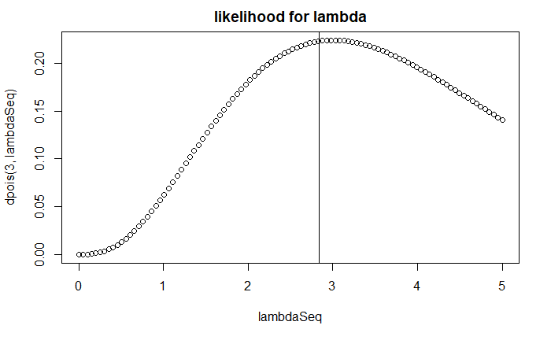

```r
lambdaSeq <- seq(from = 0, to = 5 , len = 100)
plot(lambdaSeq, dpois(3,lambdaSeq), main = "likelihood for lambda")
abline(v = lambda )
```

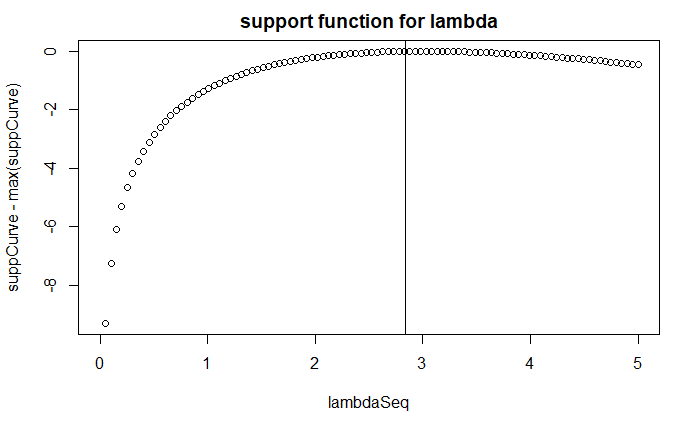

```r
suppCurve <- dpois(3, lambdaSeq, log = TRUE)
plot(lambdaSeq,suppCurve-max(suppCurve),main='support function for lambda')
abline(v=lambda)
```

We can infer that lambda = 2.83 is acceptable to be used in our model, it falls within the 2 units of support.

```r
critcalObs <- qpois(0.95, lambda )
pVal <- ppois(critcalObs,lambda )
plot(0:20, dpois( x=0:20, lambda=2.83 ), xlim=c(-2,20))
normden <- function(x){dnorm(x, mean=2.83, sd=sqrt(2.83))}
curve(normden, from=-4, to=20, add=TRUE, col="purple")
```

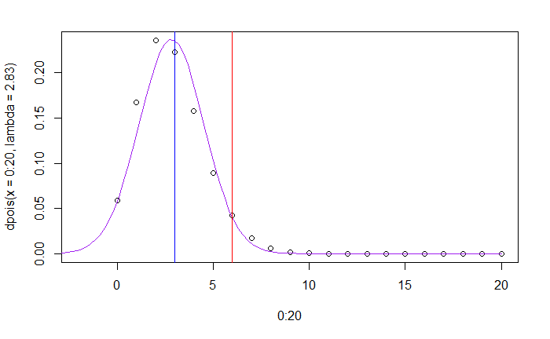

```r
abline(v=critcalObs, col = "red" )
abline(v=3, col = "blue")
```

```r
pValPois <- ppois(3,lambda, lower.tail=FALSE)
cat("The p value: ", pValPois)
```

```
The p value:  0.3169737
```

conclusion is that we fail to reject the Null

We wish to Use Pearson’s Chi Squared Test to examine whether Productivity is independent of sleeping Before 12 or after 12.

```r
library(MASS)
chiTestTbl <- table(myData$sleepTimeCatClass, myData$Total.Daily.Productivity)
chiTestTbl
```

```
    0 1.1 1.15 1.45 2 2.05 2.15 2.3 2.6 2.7 3.05 3.35 3.4 3.45 3.5 3.8 4.15 4.3 4.35 4.45 5 5.3
  A 1   1    1    1 0    0    1   0   0   0    1    0   0    3   0   0    0   0    0    0 0   0
  B 2   0    0    0 1    1    1   1   1   1    0    2   1    1   1   0    0   3    0    2 0   1
  C 1   0    0    1 0    0    0   0   0   0    0    0   0    1   0   1    1   0    1    0 1   0
```

```r
cat(chiTestTbl, "\n\n")
```

[output not shown]

```r
chisq.test(chiTestTbl)
```

```
Chi-squared approximation may be incorrect
```

```
    Pearson's Chi-squared test

data:  chiTestTbl
X-squared = 44.041, df = 42, p-value = 0.3853
```

Since the p value is 0.3853 we is greater than the significance level, we do not reject the null

```r
#make it further accurate by combining tables
newTbl <- cbind(chiTestTbl[,"0"]+chiTestTbl[,"1.1"]+chiTestTbl[,"1.15"]+chiTestTbl[,"1.45"]+chiTestTbl[,"2"]+chiTestTbl[,"2.05"]+chiTestTbl[,"2.15"],
                chiTestTbl[,"2.3"]+chiTestTbl[,"2.6"]+chiTestTbl[,"2.7"]+chiTestTbl[,"3.05"]+chiTestTbl[,"3.35"]+chiTestTbl[,"3.4"]+chiTestTbl[,"3.45"],
                chiTestTbl[,"3.4"]+chiTestTbl[,"3.8"]+chiTestTbl[,"4.15"]+chiTestTbl[,"4.3"]+chiTestTbl[,"4.35"]+chiTestTbl[,"4.45"]+chiTestTbl[,"5"]+chiTestTbl[,"5.3"])
chisq.test(newTbl)
```

```
Chi-squared approximation may be incorrect
```

```
    Pearson's Chi-squared test

data:  newTbl
X-squared = 7.2085, df = 4, p-value = 0.1253
```

```r
#cbtl <- cbind(chiTestTbl)
```

```r
#make it further accurate by combining tables into 3 groups
newTbl <- cbind(chiTestTbl[,"0"]+chiTestTbl[,"1.1"]+chiTestTbl[,"1.15"]+chiTestTbl[,"1.45"]+chiTestTbl[,"2"]+chiTestTbl[,"2.05"]+chiTestTbl[,"2.15"]+ chiTestTbl[,"2.3"]+chiTestTbl[,"2.6"]+chiTestTbl[,"2.7"],
                chiTestTbl[,"3.05"]+chiTestTbl[,"3.35"]+chiTestTbl[,"3.4"]+chiTestTbl[,"3.45"]+chiTestTbl[,"3.4"]+chiTestTbl[,"3.8"]+chiTestTbl[,"4.15"]+chiTestTbl[,"4.3"]+chiTestTbl[,"4.35"]+chiTestTbl[,"4.45"]+
                chiTestTbl[,"5"]+chiTestTbl[,"5.3"])
chisq.test(newTbl)
```

```
Chi-squared approximation may be incorrect
```

```
    Pearson's Chi-squared test

data:  newTbl
X-squared = 1.1803, df = 2, p-value = 0.5542
```

```r
#cbtl <- cbind(chiTestTbl)
```

```r
expect <- c()
obs <- c()
```

```r
mean(myData$Total.Daily.Productivity)
```

```
[1] 2.84
```